# MATH 530/630

Integrative Lab 1 - Example Exploratory Data Analysis

**Self-Assessment**

How to:

- Start with your initial submission, and save it as a new file. Then add a sub-section to each of the sections with content called “Self-Assessment”.
- You may want to add color formatting to further highlight the self-assessment section. You can change the color of the font by using `<span style="color:deeppink">` span styles like this `</span>`.
- If you want to change the color of a bulleted list, change `span` to `ul` and use the same method (pick any [color](http://www.stat.columbia.edu/~tzheng/files/Rcolor.pdf)).
- My code is provided here so that you can problem solve- if you need to copy and paste, do so in your self-assessment section, but you’ll need to include narrative including attribution and reflection on *what* part of that code chunk you struggled with and *why*.My code below is just an example and your data analysis should be based on the dataset you have been working with. If you feel your answers are perfect and need no correction, in the subsection just leave a comment that you are happy with your results/work.

`

**Integrative Lab 1 - Exploratory Data Analysis**

###Reprohealth dataset ####Download the below libraries required for the exploration of the reprohealth dataset

```r
library(tidyverse)
library(skimr)
library(readxl)
library(here)
library(janitor)
library(knitr)
library(remotes)
library(reprohealth)
```

##Explore the wb_reprohealth data

Load the dataset and read it.

```r
wb_stats <- wb_reprohealth %>%
  mutate(year = parse_number(year))
head(wb_stats,n=3)#retrieve the first three elements in the dataset
```

```
## # A tibble: 3 x 9
##    year country continent region edu_gen_parity gdp_per_cap life_exp
##   <dbl> <chr>   <chr>     <chr>           <dbl>       <dbl>    <dbl>
## 1  2000 Afghan~ Asia      South~             NA         NA      56.7
## 2  2001 Afghan~ Asia      South~              0        117.     57.2
## 3  2002 Afghan~ Asia      South~             NA        188.     57.8
## # ... with 2 more variables: mat_mortality <dbl>, tot_fertility <dbl>
```

The below questions can be answered using “skim” from the skimr package. Alternatively, I’ve included code to answer each question individually.

```r
skim(wb_stats)
```

```
## Skim summary statistics
##  n obs: 3296
##  n variables: 9
##
## -- Variable type:character ------------------------------------------------------------------------------------------------
##   variable missing complete    n min max empty n_unique
##  continent       0     3296 3296   4   8     0        5
##    country       0     3296 3296   4  32     0      206
##     region       0     3296 3296   9  25     0       22
##
## -- Variable type:numeric --------------------------------------------------------------------------------------------------
##        variable missing complete    n     mean        sd      p0     p25
##  edu_gen_parity    1122     2174 3296     0.97     0.093    0       0.97
##     gdp_per_cap     122     3174 3296 13018.62 20018.95   111.36 1156.49
##        life_exp     139     3157 3296    71.96     9.81    39.76   65.56
##   mat_mortality     368     2928 3296   214.69   299.78     3      16
##   tot_fertility     126     3170 3296     2.99     1.57     0.83    1.77
##            year       0     3296 3296  2007.5      4.61  2000    2003.75
##      p50      p75      p100     hist
##     1        1.02      1.25 ▁▁▁▁▁▁▇▁
##  4111.75 15954.62 179308.08 ▇▁▁▁▁▁▁▁
##    74.95    79.06     87.3  ▁▁▂▂▂▅▇▃
##    64      335      2650    ▇▂▁▁▁▁▁▁
##     2.45     4.02      7.68 ▅▇▃▂▂▂▁▁
##  2007.5   2011.25   2015    ▇▇▇▇▇▇▇▇
```

NOTE: please disregard the lack of pretty skim histograms - it’s a knitting in Windows issue.

1.How many variables/columns?

There are 9 variables in the dataset

```r
ncol(wb_stats)
```

```
## [1] 9
```

```r
colnames(wb_stats)
```

```
## [1] "year"           "country"        "continent"      "region"
## [5] "edu_gen_parity" "gdp_per_cap"    "life_exp"       "mat_mortality"
## [9] "tot_fertility"
```

2.How many rows/observations?

There are 3296 observations in the dataset

```r
nrow(wb_stats)
```

```
## [1] 3296
```

You can also use the below dim() command to find out the rows and the columns.

```r
dim(wb_stats)
```

```
## [1] 3296    9
```

3.Which variables are numbers?

Out of the 9 variables,we have 6 number variables in the dataset.

```r
number_variables = wb_stats %>% select_if(is.numeric) %>% colnames()
number_variables
```

```
## [1] "year"           "edu_gen_parity" "gdp_per_cap"    "life_exp"
## [5] "mat_mortality"  "tot_fertility"
```

4.Which are categorical variables (numeric or character variables with variables that have a fixed and known set of possible values; aka factor variables)?

We have 3 categorical variables in the dataset.

```r
categorical_variables = wb_stats %>% select_if(is.character) %>% colnames()
categorical_variables
```

```
## [1] "country"   "continent" "region"
```

5. There is one row per country for each year.

#Gapminder Dataset ##Load your choice of gapminder dataset. I have used the Gapminder data - life expectancy at birth dataset. Life expectancy at birth is defined as how long, on average, a newborn can expect to live, if current death rates do not change. Life expectancy at birth is one of the most frequently used health status indicators.

Load the dataset and read it

```r
Life_expectancy <- read_xlsx(here::here("data", "life_expectancy_years.xlsx"),
                      sheet = 1) %>% clean_names()
```

###Answer the same 5 questions as you did above for the reprohealth data. NOTE: Not using skim here - try it and you’ll see why!

1.How many variables/columns?

+There are 220 variables in the dataset

```r
ncol(Life_expectancy)
```

```
## [1] 220
```

2.How many rows/observations?

+There are 187 observations in the dataset

```r
nrow(Life_expectancy)
```

```
## [1] 187
```

3.Which variables are numbers?

- Out of the 220 variables,we have 219 number variables in the dataset.

```r
number_variables = Life_expectancy %>% select_if(is.numeric) %>% colnames()
head(number_variables,4)#displaying only 4 variables
```

```
## [1] "x1800" "x1801" "x1802" "x1803"
```

4.Which are categorical variables (numeric or character variables with variables that have a fixed and known set of possible values; aka factor variables)?

- We have 1 categorical variable in the dataset.

```r
categorical_variables = Life_expectancy %>% select_if(is.character) %>% colnames()
categorical_variables
```

```
## [1] "geo"
```

5.There is one row per country.

##Join this new data using dplyr with the reprohealth data you have been working with, and make some observations about the process and result.

###Use dplyr::gather() to convert data from wide format into long.

```r
lifeExp_tidy <- Life_expectancy %>%
   dplyr::select(country = 1, everything()) %>%
  gather(year, life_exp, -country,convert = TRUE) %>%
  mutate(year = readr::parse_number(year))
head(lifeExp_tidy,3)
```

```
## # A tibble: 3 x 3
##   country      year life_exp
##   <chr>       <dbl>    <dbl>
## 1 Afghanistan  1800     28.2
## 2 Albania      1800     35.4
## 3 Algeria      1800     28.8
```

reprohealth dataset contains data from 2000 - 2015

lifeexpectancy dataset contains data from 1800 - 2018

For my analysis, I have filtered the life expectancy dataset between 2000 - 2018

```r
lifeExp_tidy_filter <- lifeExp_tidy %>%
  filter(year %>% between(2000, 2018))
head(lifeExp_tidy_filter,3)
```

```
## # A tibble: 3 x 3
##   country      year life_exp
##   <chr>       <dbl>    <dbl>
## 1 Afghanistan  2000     51.6
## 2 Albania      2000     74.4
## 3 Algeria      2000     73.9
```

##Using merge in R 1.Natural join: To keep only rows that match from the data frames, specify the argument all=FALSE.

2.Full outer join:To keep all rows from both data frames, specify all=TRUE.

```r
merge_data <- merge(wb_stats, lifeExp_tidy_filter, by=c("year", "country"), all.x = TRUE)


#Since this is an example, for this analysis I have omitted the NA's in my dataset.

merge_data_omit <- na.omit(merge_data)
head(merge_data_omit,3)
```

```
##   year   country continent          region edu_gen_parity gdp_per_cap
## 2 2000   Albania    Europe Southern Europe        0.96296    1175.789
## 3 2000   Algeria    Africa Northern Africa        0.96405    1757.018
## 7 2000 Argentina  Americas   South America        1.02402    7669.274
##   life_exp.x mat_mortality tot_fertility life_exp.y
## 2     76.953            43         2.157       74.4
## 3     71.748           170         2.514       73.9
## 7     77.544            60         2.561       74.2
```

#Explore questions

```r
 merge_data_omit %>%
  group_by(continent) %>%
  dplyr::summarise(n_levels = n()) %>%
  mutate(Proportions = n_levels/sum(n_levels) )
```

```
## # A tibble: 5 x 3
##   continent n_levels Proportions
##   <chr>        <int>       <dbl>
## 1 Africa         470      0.250
## 2 Americas       375      0.199
## 3 Asia           430      0.229
## 4 Europe         528      0.281
## 5 Oceania         78      0.0415
```

###1.Get the maximum and minimum of children per woman (tot_fertility) for all continents.

As we can see from the below results, there has been some variations in the fertility rate in continents like Africa and Asia with the maximum children per household being seven to minimum being one. You can further analyze these variations by calculating the variations within the continent level.

```r
fertility_continent <- merge_data_omit %>%
  filter(!is.na(tot_fertility)) %>%
  group_by(continent) %>%
  summarize(min_fertility = min(tot_fertility), max_fertility = max(tot_fertility)) %>%
  arrange(min_fertility, max_fertility)
fertility_continent
```

```
## # A tibble: 5 x 3
##   continent min_fertility max_fertility
##   <chr>             <dbl>         <dbl>
## 1 Asia               1.08          7.39
## 2 Europe             1.08          2.23
## 3 Africa             1.36          7.68
## 4 Americas           1.49          4.60
## 5 Oceania            1.81          4.72
```

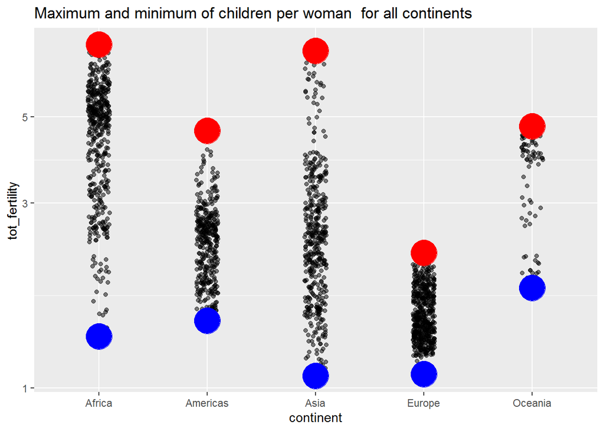

```r
ggplot(merge_data_omit, aes(x = continent, y = tot_fertility)) +
  scale_y_log10() +
  geom_jitter(position = position_jitter(width = 0.1), alpha = 0.5) +
  geom_point(data = fertility_continent, aes(x = continent, y = min_fertility), colour = "blue", size = 10) +
  geom_point(data = fertility_continent, aes(x = continent, y = max_fertility), colour = "red", size = 10)+
  ggtitle("Maximum and minimum of children per woman  for all continents")
```

###2.Look at the spread of children per woman (tot_fertility) across countries within the continents.

As discussed in the classroom, spread of the data can be calculated using Standard Deviation, Interquartile range and Median Absolute Deviation. To analyze the spread across the countries within the continent, group the data by continent and country

In the below r chunk, we calculate the spread of the data within the continent level. Africa and Asia have high standard deviation followed by the rest of the continents. The average deviation seems to be on the larger side.

```r
continent_fertility_spread <- merge_data_omit %>%
  filter(!is.na(tot_fertility)) %>%
  group_by(continent) %>%
  summarise( Std = sd(tot_fertility),Interquartile=IQR(tot_fertility))
continent_fertility_spread
```

```
## # A tibble: 5 x 3
##   continent   Std Interquartile
##   <chr>     <dbl>         <dbl>
## 1 Africa    1.47          2.35
## 2 Americas  0.555         0.719
## 3 Asia      1.20          1.27
## 4 Europe    0.239         0.390
## 5 Oceania   0.920         1.49
```

As we can see from the below plot, the fertility rate of Africa has spread across the graph with the number of children per household ranging form 2 to 8, but it is densely populated on the heavier side with children 4 and more per household. In continents like Americas and Oceania, we can see the average children per household to be 4 or less.

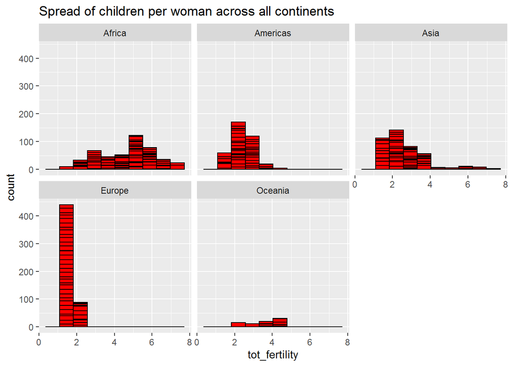

```r
plot_spread <- ggplot(merge_data_omit,aes(x=tot_fertility,by=country)) +
  facet_wrap(~continent) +
  geom_histogram(col="black",fill = "red",bins = 10) +
  ggtitle("Spread of children per woman across all continents")
plot_spread
```

```r
fertility_spread <- merge_data_omit %>%
  group_by(continent,country) %>%
  summarise( Std = sd(tot_fertility), IRange= IQR(tot_fertility),medianabs= mad(tot_fertility))
head(fertility_spread,3)
```

```
## # A tibble: 3 x 5
## # Groups:   continent [1]
##   continent country    Std IRange medianabs
##   <chr>     <chr>    <dbl>  <dbl>     <dbl>
## 1 Africa    Algeria 0.194   0.331     0.191
## 2 Africa    Angola  0.0970  0.113     0.107
## 3 Africa    Benin   0.362   0.637     0.402
```

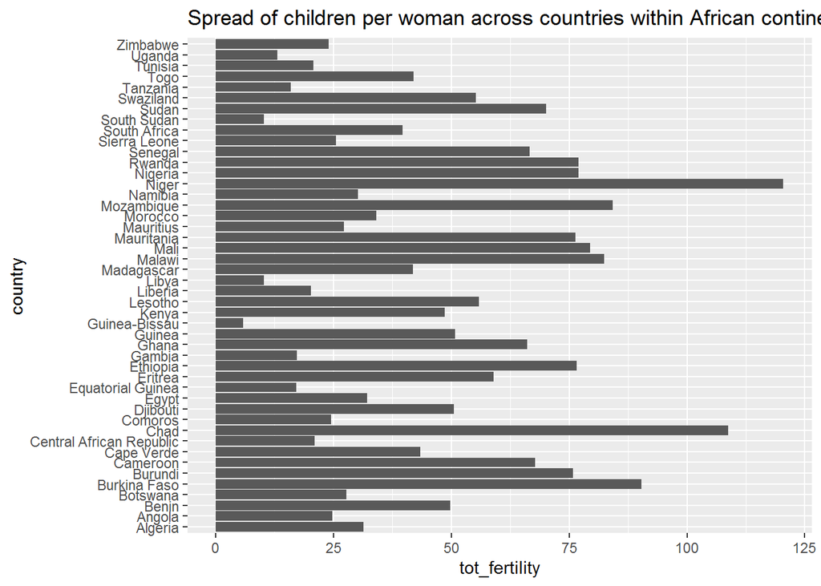

```r
filter_continent <-merge_data_omit %>%
  filter(continent=="Africa")

filter_continent %>%
  ggplot(aes(x=country, y=tot_fertility))+geom_bar(stat="identity") +
  coord_flip() +
  ggtitle("Spread of children per woman across countries within African continent")
```

###3.Compute a trimmed mean of maternal mortality (mat_mortality) for different years. Or a weighted mean, weighting by population. Just trying something other than the plain vanilla mean.

```r
trimfactor <- 0.05
trimmean <-merge_data_omit %>% group_by(year) %>%
  summarise(mean_regular=mean(mat_mortality),mean_trimmed = mean(mat_mortality, trimfactor))

head(trimmean,3)
```

```
## # A tibble: 3 x 3
##    year mean_regular mean_trimmed
##   <dbl>        <dbl>        <dbl>
## 1  2000         215.         182.
## 2  2001         246.         201.
## 3  2002         200.         172.
```

Plot the trimmed_mean change over the years and, as you can see from the below plot, the mortality rate has been gradually decreasing over a period of years.

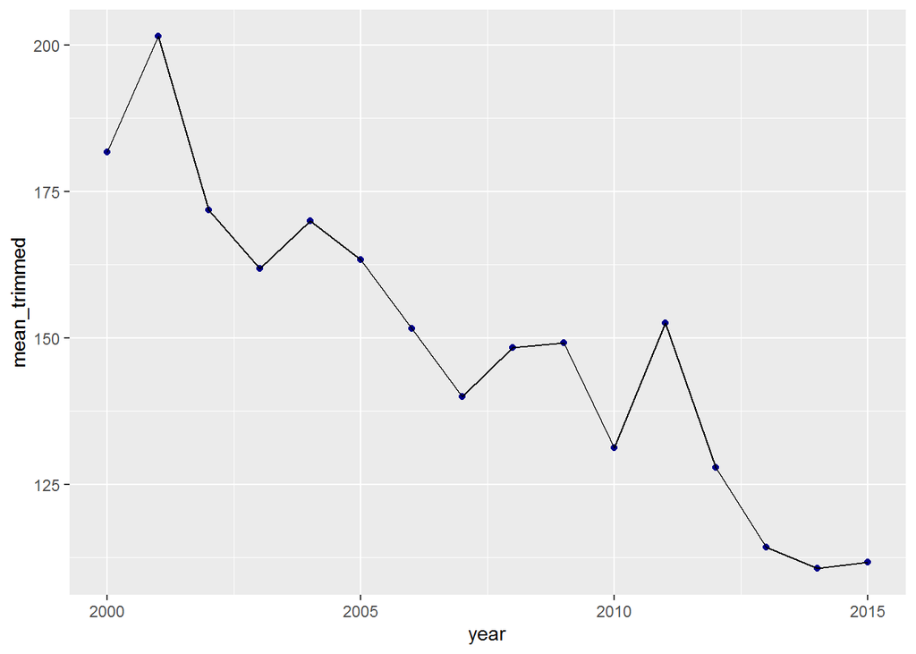

```r
trimmean %>% ggplot(aes(x=year,y=mean_trimmed))+geom_point(color="darkblue")+geom_line()
```

4.How does maternal mortality (mat_mortality) vary across different continents?

```r
summary(merge_data_omit$mat_mortality)
```

```
##    Min. 1st Qu.  Median    Mean 3rd Qu.    Max.
##     3.0    13.0    44.0   179.5   229.0  2530.0
```

Group by the continent and year, then calculate the median mortality rate

```r
mat_mortal <- merge_data_omit %>%
  group_by(continent,year) %>%
  dplyr::summarise(mat_avg=median(mat_mortality))
head(mat_mortal,3)
```

```
## # A tibble: 3 x 3
## # Groups:   continent [1]
##   continent  year mat_avg
##   <chr>     <dbl>   <dbl>
## 1 Africa     2000     590
## 2 Africa     2001     597
## 3 Africa     2002     575
```

Converting the data from long format into wide

```r
mat_wide <- spread(mat_mortal, year, mat_avg)
mat_wide
```

```
## # A tibble: 5 x 17
## # Groups:   continent [5]
##   continent `2000` `2001` `2002` `2003` `2004` `2005` `2006` `2007` `2008`
##   <chr>      <dbl>  <dbl>  <dbl>  <dbl>  <dbl>  <dbl>  <dbl>  <dbl>  <dbl>
## 1 Africa     590    597      575    519    536    508   514.  488.   606
## 2 Americas    79     86       67     62     69     67    69    67.5   69.5
## 3 Asia        46.5   56       43     48     43     37    40    39     38
## 4 Europe      12     11.5     11     11     11     11    10    10      9.5
## 5 Oceania     97     94      102     82     79    106    96    96.5   77.5
## # ... with 7 more variables: `2009` <dbl>, `2010` <dbl>, `2011` <dbl>,
## #   `2012` <dbl>, `2013` <dbl>, `2014` <dbl>, `2015` <dbl>
```

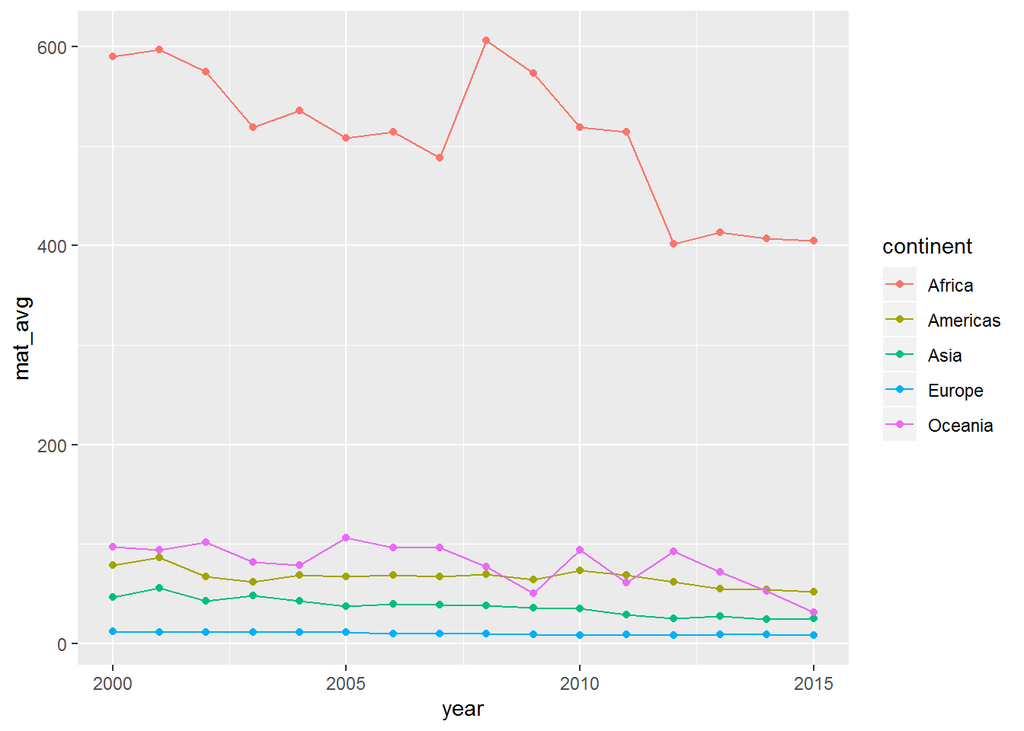

```r
mat_mortality_data <- ggplot(mat_mortal, aes(x=year, y=mat_avg, color=continent))+ geom_point()+geom_line()
mat_mortality_data
```

###5.Report the absolute and/or relative abundance of countries with low maternal mortality (mat_mortality) over time by continent: Compute some measure of worldwide maternal mortality - you decide - a mean or median or some other quantile or perhaps your current age. Then determine how many countries on each continent have a maternal mortality rate less than this benchmark, for each year.

I have chosen the benchmark to be the median of the motality rate. Then subset the dataset with mortality rate less than the benchmark and find out the number of countries that falls below the benchmark.

```r
measure_mortality <- median(merge_data_omit$mat_mortality)

mat_long_mortality<-merge_data_omit %>%
  group_by(continent,year) %>%
  dplyr::summarise(count=sum(mat_mortality < measure_mortality, na.rm=T),
    proportion=round(sum(mat_mortality < measure_mortality, na.rm=T)/length(mat_mortality), 2))
head(mat_long_mortality,3)
```

```
## # A tibble: 3 x 4
## # Groups:   continent [1]
##   continent  year count proportion
##   <chr>     <dbl> <int>      <dbl>
## 1 Africa     2000     1       0.03
## 2 Africa     2001     1       0.03
## 3 Africa     2002     2       0.06
```

Filtering the mortality rate for Europe and finding the proportion of countries with low mortality rate.

```r
europe_mortality <- mat_long_mortality %>% filter(continent=="Europe")
tail(europe_mortality,3)
```

```
## # A tibble: 3 x 4
## # Groups:   continent [1]
##   continent  year count proportion
##   <chr>     <dbl> <int>      <dbl>
## 1 Europe     2013    31          1
## 2 Europe     2014    32          1
## 3 Europe     2015    34          1
```

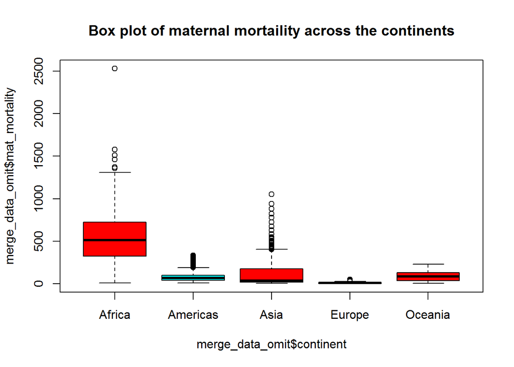

```r
boxplot(merge_data_omit$mat_mortality~merge_data_omit$continent,col= rainbow(2),main = "Box plot of maternal mortaility across the continents")
```